# Pleistocene climate oscillations and habitat connectivity contributed to avian beta‐diversity in the megadiverse Colombian Paramo ecosystems - Calpa‐Anaguano - - Journal of Biogeography - Wiley Online

[figure not shown]

RESEARCH ARTICLE

Free Access

# Pleistocene climate oscillations and habitat connectivity contributed to avian beta-diversity in the megadiverse Colombian Paramo ecosystems

[Edna V. Calpa-Anaguano](https://onlinelibrary.wiley.com/action/doSearch?ContribAuthorRaw=Calpa-Anaguano%2C+Edna+V),

[Catherine H. Graham](https://onlinelibrary.wiley.com/action/doSearch?ContribAuthorRaw=Graham%2C+Catherine+H),

[Fernando R. da Silva](https://onlinelibrary.wiley.com/action/doSearch?ContribAuthorRaw=Silva%2C+Fernando+R),

First published: 26 October 2021

https://doi.org/10.1111/jbi.14251

**Handling Editor:** : Walter Jetz

## Abstract

### Aim

The role of evolutionary history in shaping the patterns of species distributions is generally explored at coarse spatial extents. However, at small spatial extents, the combined effects of history and ecological processes on local diversity has received less attention. We test the relative importance of historical and ecological factors on the spatial distribution of bird taxonomic (TβD) and phylogenetic (PβD) β-diversity on Paramo ecosystems.

### Location

South-western Colombia.

### Taxon

Andean bird species.

### Results

Two-thirds of the bird species in the paramos are recent and emerged after the late Miocene/early Pliocene. The average TβD was four times higher than the average PβD indicating that paramo assemblages harbour distinct, but closely related, species. We found that distribution of β-diversity had a spatial structure resulting in two groups of paramos – one in the north of our study area containing four paramos and other in the south with seven paramos. This spatial structure together with past climate conditions explained the variation of both TβD and PβD.

### Main conclusions

Our results are consistent with the hypothesis that patterns of β-diversity reflect the complex history of Andean region including mountain uplift and climatic oscillations in the Pleistocene. We demonstrated that the integration of different facets of β-diversity into a community ecology framework provides new insights about the historical and ecological factors responsible for generating the patterns of species distribution.

## 1 INTRODUCTION

A key challenge in ecological research is determining the relative importance of historical and contemporary processes in shaping geographical variation in biodiversity (HilleRisLambers et al., 2012; Ricklefs, 1987; Wiens & Donoghue, 2004). On the one hand, historical factors, such as uplift of mountain ranges and Quaternary climatic oscillations, impacted the rates of speciation, extinction and dispersal, affecting species richness and composition (Benício et al., 2021; Graham et al., 2006; Hoorn et al., 2010; Rangel et al., 2018; Ricklefs, 1987). On the other hand, contemporary factors, such as species–environment associations and species interactions, determine which species can coexist in a given assemblage (HilleRisLambers et al., 2012; Weiher & Keddy, 1995). Evaluating multiple dimensions (e.g. taxonomic and phylogenetic) of β-diversity (i.e. variation in species composition between two communities) is a promising approach to tease apart the importance of historical and contemporary processes that generate and maintain patterns of species distributions (Benício et al., 2021; da Silva et al., 2014; Graham & Fine, 2008; Penone et al., 2016; Qian et al., 2013; Swenson et al., 2012; Weinstein et al., 2014). For example, Weinstein et al. (2014) found that high β-diversity in all dimensions resulted from hummingbird adaptation to different environments in isolated assemblages in the northern Andes. Da Silva et al. (2014), in an evaluation of taxonomic and phylogenetic β-diversity, found that speciation, environmental filtering and dispersal limitation were complementary drivers of amphibian assemblages in the Brazilian Atlantic Forest. These examples withstanding, multiple dimensions of β-diversity have been poorly explored in mountain regions that are considered cradles (i.e. areas of especially rapid species origination), museums (i.e. areas of especially long-term persistence of species) and graves (i.e. areas with especially high rates of extinction) of biodiversity (Fjeldså et al., 2012; Rahbek, Borregaard, Antonelli, et al., 2019; Rahbek, Borregaard, Colwell, et al., 2019; Rangel et al., 2018).

The paramo ecosystem in the tropical Andes of South America is an excellent study system for evaluating the importance of historical and contemporary processes shaping current patterns of species distributions. The paramo ecosystem hosts many threatened bird species (Fundación ProAves, 2014), and thus, greater knowledge about the origin and maintenance of its diversity is critical for conservation. This ecosystem, dominated by grasslands above the forest tree-line on isolated mountain-tops above 2800–4700 m from Costa Rica to Peru, has been divided into 11 biogeographic districts (Hazzi et al., 2018; Madriñán et al., 2013). The timing of mountain building in the northern Andes (from ~23 to 6 Ma, Gregory-Wodzicki, 2000; Hoorn et al., 2010), in conjunction with Pleistocene climatic oscillations, had a strong effect on the diversification of Andean biota (Fjeldså et al., 2012; Hazzi et al., 2018; Madriñán et al., 2013; Van der Hammen, 1974). In particular, the final phase of the Andean uplift during the late Miocene/early Pliocene (Gregory-Wodzicki, 2000) created isolated ‘sky islands’ surrounded by drier valleys, which act as dispersal barriers (Hazzi et al., 2018). Quaternary climate change caused repeated range expansion and contraction, allowing down-slope migration through the drier valleys (Hazzi et al., 2018; Hooghiemstra et al., 2006; Van der Hammen, 1974). Under this scenario, speciation rates were not constant over time but were related to historical events (Weir, 2006). Information contained in time-calibrated phylogenies, allows us to explore if increases in speciation are associated with the Andean uplift and historical connectivity of paramos (Paradis, 1997; Rabosky, 2006).

Most studies exploring the influence of historical events on the origin and maintenance of paramo biodiversity have considered the entire paramo region, making it difficult to evaluate small-scale ecological processes. Evaluating smaller spatial extents provides the opportunity to integrate biogeographical and ecological approaches to infer the role of different processes generating bird diversity (e.g. Benício et al., 2021; Ricklefs & Jenkins, 2011; Warren et al., 2014; Weeks et al., 2016). The spatial distribution of β-diversity provides insight into the relative importance of historical mechanism, such as speciation, and contemporary ones, notably dispersal, on spatial variation among paramo assemblages. Speciation and dispersal can generate four scenarios related to spatial distribution of taxonomic (TβD) and phylogenetic (PβD) beta diversities (Figure S1): (i) high TβD and low PβD – paramo assemblages may have different species compositions but harbour closely related species due to recent allopatric speciation in historical connected among assemblages; (ii) high TβD and PβD – paramo assemblages may harbour completely different lineages (taxonomic and phylogenetic β-diversity; Graham & Fine, 2008) due to in situ radiation and long-term geographic barriers limiting recent historical connectivity; (iii) low TβD and high PβD – paramo assemblages may harbour phylogenetically distinct species with small geographic ranges which are dispersal limited by geographic barriers (e.g. relic population that persisted in only a few places) and (iv) low TβD and PβD – paramo assemblages may have similar species composition (i.e. biotic homogenization) due to no dispersal limitation.

Here, we test the relative importance of these historical and ecological factors on the spatial distribution of bird taxonomic and phylogenetic β-diversity based on 11 paramo ecosystems of south-western Colombia. Colombia contains the most extensive area of paramos in the Neotropics including seven of the eleven biogeographic districts delimited based on the distributional data of 4644 vertebrate and angiosperm species (Jiménez-Rivillas et al., 2018). The study region encompasses the Colombian massif and ‘Nudo de los Pastos’ which meet at the intersection of distinct cordilleras. Given their unique geographic position, they have been recognized as a hotspot of diversification and endemism (Delgado et al., 2008; González-Orozco, 2021; Hazzi et al., 2018; Jiménez-Rivillas et al., 2018; Morales et al., 2007). We hypothesize that the geographic position at the intersection of cordilleras and Pleistocene climatic oscillation are important factors associated with the current patterns of species distributions (Fjeldså et al., 2012; Hazzi et al., 2018; Kattan et al., 2004; Van der Hammen, 1974). Specifically, we predict that taxonomic β-diversity will be high between assemblages due to dry valleys constraining dispersal across paramos ecosystems. This is expected because mountains surrounded by dry valleys have increased speciation rates and endemism compared with those surrounded by mesic habitats (e.g. Fjeldså et al., 2012; Hoorn et al., 2010; Jetz et al., 2012; Quintero & Jetz, 2018; Figure 1). Conversely, we predict that low phylogenetic β-diversity between assemblages is due to the down-slope dispersal of bird lineages through the drier valleys during climatic oscillations that facilitated past connection between neighbouring paramos (Hazzi et al., 2018; Van der Hammen, 1974; Figure 1). Based on this scenario, we expect a positive association between phylogenetic β-diversity and geographical distance (e.g. distance decay of similarity; Nekola & White, 1999). Furthermore, we predict that current climatic variation will be associated with spatial distribution of taxonomic and phylogenetic β-diversity if there are no barriers constraining species dispersal among paramos. In this case, species composition will vary in relation to differences among local conditions of paramos and the successful establishment of any species will depend on its physiological tolerance to climatic conditions or other mechanisms such as biotic interactions (e.g. Keddy, 1992).

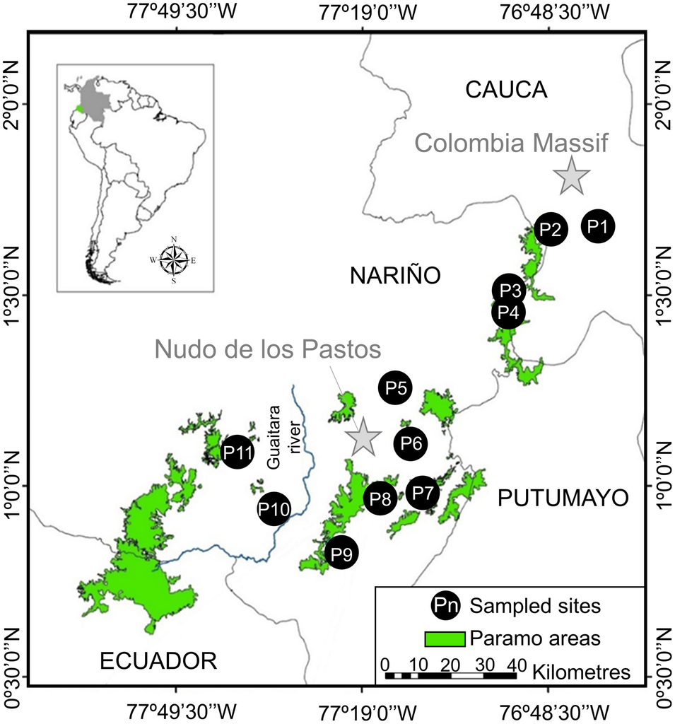

**FIGURE 1**

## 2 MATERIALS AND METHODS

### 2.1 Study area

Bird occurrences were recorded in 11 paramos in the Andes mountain range over the Colombian massif and ‘Nudo de los Pastos’ in Nariño and Cauca departments (see Figure 1; Table 1; Table S1). Colombian massif and ‘Nudo de los Pastos’ have a tectonic origin with volcanic geomorphological formations located within the Paramo biogeographic province (González-Orozco, 2021; IGAC, 1997; Morrone, 2014) and Narinõ – Putumayo district (sensu Morales et al., 2007). The Colombian massif and ‘Nudo de los Pastos’ have a key role in Colombia biogeography because they are at the intersection of mountain cordilleras. The Colombian massif contains the intersection between the Central and Eastern Cordilleras while the ‘Nudo de los Pastos’ contains the intersection between the Central and Western Cordillera (Delgado et al., 2008; Morales et al., 2007). There is mounting evidence that the intersections of cordilleras, together with alterations in the vegetation during glacial periods and active volcanic activities, have resulted in isolation of biotas contributing to high rates of diversification and endemism in this region (Delgado et al., 2008; Hazzi et al., 2018; Morales et al., 2007; Stattersfield et al., 1998).

| Sites | Geographical coordinates Latitude | Geographical coordinates Longitude | Altitude MIAL | Altitude MAAL | Altitude RAAL | Current climate AMT | Current climate MDR | Current climate TS | Current climate TAR | Current climate AP | Current climate PS | Current climate PWQ | Current climate PCQ | Last Glacial Maximum (LGM) AMT | Last Glacial Maximum (LGM) MDR | Last Glacial Maximum (LGM) TS | Last Glacial Maximum (LGM) TAR | Last Glacial Maximum (LGM) AP | Last Glacial Maximum (LGM) PS | Last Glacial Maximum (LGM) PWQ | Last Glacial Maximum (LGM) PCQ |
| --- | --- | --- | --- | --- | --- | --- | --- | --- | --- | --- | --- | --- | --- | --- | --- | --- | --- | --- | --- | --- | --- |
| P1 | 1.701 | −76.693 | 2677 | 3188 | 511 | 116 | 93 | 337 | 103 | 1901 | 16 | 524 | 463 | 99 | 407 | 94 | 122 | 353 | 17 | 101 | 561 |
| P2 | 1.692 | −76.820 | 2978 | 3606 | 628 | 86 | 86 | 392 | 97 | 2312 | 22 | 640 | 619 | 70 | 454 | 64 | 138 | 357 | 22 | 71 | 798 |
| P3 | 1.52 | −76.935 | 3003 | 3604 | 601 | 86 | 84 | 359 | 93 | 2415 | 22 | 679 | 643 | 71 | 466 | 64 | 143 | 382 | 23 | 71 | 844 |
| P4 | 1.475 | −76.940 | 2618 | 3381 | 763 | 87 | 84 | 392 | 93 | 2465 | 23 | 691 | 672 | 71 | 463 | 65 | 143 | 410 | 25 | 71 | 874 |
| P5 | 1.269 | −77.240 | 3280 | 3520 | 240 | 105 | 84 | 358 | 93 | 1781 | 18 | 530 | 386 | 91 | 387 | 85 | 116 | 335 | 18 | 91 | 551 |
| P6 | 1.122 | −77.208 | 3198 | 3551 | 353 | 105 | 85 | 400 | 95 | 1789 | 19 | 515 | 462 | 91 | 350 | 84 | 112 | 409 | 21 | 92 | 585 |
| P7 | 0.997 | −77.180 | 2798 | 2819 | 21 | 111 | 87 | 440 | 99 | 1666 | 22 | 469 | 460 | 97 | 307 | 90 | 98 | 434 | 23 | 98 | 541 |
| P8 | 0.987 | −77.293 | 3078 | 3504 | 426 | 77 | 83 | 466 | 95 | 1875 | 21 | 544 | 495 | 63 | 340 | 56 | 108 | 446 | 22 | 64 | 597 |
| P9 | 0.844 | −77.397 | 2909 | 3400 | 491 | 90 | 87 | 468 | 100 | 1564 | 18 | 458 | 395 | 76 | 294 | 68 | 94 | 473 | 19 | 77 | 462 |
| P10 | 0.956 | −77.577 | 3171 | 3408 | 237 | 108 | 93 | 427 | 105 | 1100 | 24 | 337 | 194 | 95 | 177 | 88 | 55 | 427 | 26 | 88 | 320 |
| P11 | 1.104 | −77.672 | 3202 | 3415 | 213 | 80 | 85 | 331 | 94 | 1493 | 25 | 475 | 254 | 67 | 254 | 62 | 74 | 337 | 26 | 62 | 481 |

### Note

- Minimum altitude (MIAL; m); maximum altitude (MAAL; m), altitudinal range (RAAL; m); annual mean temperature (AMT; °C*10); mean diurnal range (MDR; °C*10); temperature seasonality (TS; °C*10); temperature annual range (TAR; °C*10); annual precipitation (AP; mm); precipitation seasonality (PS; mm), precipitation of warmest quarter (PWQ; mm); precipitation of coldest quarter (PCQ; mm).

The average linear geographic distance between the 11 paramos we evaluated is 53.5 ± 30.5 km. In each paramo, four sampling stations were delimited along an altitudinal transect encompassing zones and ecotones of Andean high forest, shrubland, and grassland (Figure 1). We used GPS elevation data of the first and fourth sampling stations along the altitudinal transect in each paramo (Figure 1; Table 1) to determine maximum altitude (MAAL-station 1), minimum altitude (MIAL-station 4) and altitudinal range (difference between MAAL and MIAL: RAAL).

### 2.2 Bird distribution data

Bird sampling was carried out within each of the 11 paramos for 7 to 9 days from January to July 2015 using visual and auditory surveys, and mist nets. Surveys were done during peak bird activity from 5:30 to 9:30 h and from 15:30 to 18:30 h, using 6 count points of 25 m radius in each sampling station of dense habitats (high Andean forest and dense shrubs stations) and 50 m of radius in each station of low shrubs and grasslands. Count points were separated by 150 m. Mist nets (12 m × 2.5 m and 32 mm mesh eye) were placed between the counting points. Nets were opened for 6–18 h over 9 days. All sampling was done on days without extensive rain or wind following standard avian sampling protocols. These data form part of a large project of the Universidad de Nariño, Instituto de Investigación de Recursos Biológicos Alexander von Humboldt, 2016 where they are curated and made publicly available (2016, http://doi.org/10.15472/zmnvox).

In total, 175 bird species were recorded in 11 paramos (Table S2). Given that our study area was relatively small most species have geographical distributions that extend beyond the study area (Calderón-Leytón et al., 2011). However, considering that we are interested in how historical and ecological processes have shaped the current spatial distribution of taxonomic and phylogenetic assemblages at small spatial extent, evaluating only part of species geographical distribution does not affect our findings.

#### 2.2.1 Current climate conditions

We obtained current climate variables from WorldClim 2 (Fick & Hijmans; https://www.worldclim.org/) at 1 km spatial resolution (Table S2). We selected eight climatic variables based on previous studies that evaluated Andean bird distributions (e.g. Graham et al., 2009, 2010; Leprieur et al., 2012; Table S2): annual mean temperature (AMT), mean diurnal range (MDR), temperature seasonality (TS), temperature annual range (TAR), annual precipitation (AP), precipitation seasonality (PS), precipitation of warmest quarter (PWQ), precipitation of coldest quarter (PCQ). We calculated difference between Pleistocene and current climate variables to determine the climatic oscillation over time.

#### 2.2.2 Past climate conditions

We obtained climatic variables of the last glacial maximum (LGM) 22,000 years ago (Community Climate System Model – CCSM4) from WorldClim 2 (Fick & Hijmans, 2017) at 1 km spatial resolution (Table S2). We selected the same eight climatic variables extracted for current climatic conditions. Following Godinho and da Silva (2018), we subtracted LGM from current climate variables to determine the climatic oscillation over this period. Negative values indicate that climate variables are higher currently than in the past, whereas positive values indicate that climate variables were higher in the past than currently.

#### 2.2.3 Connectivity

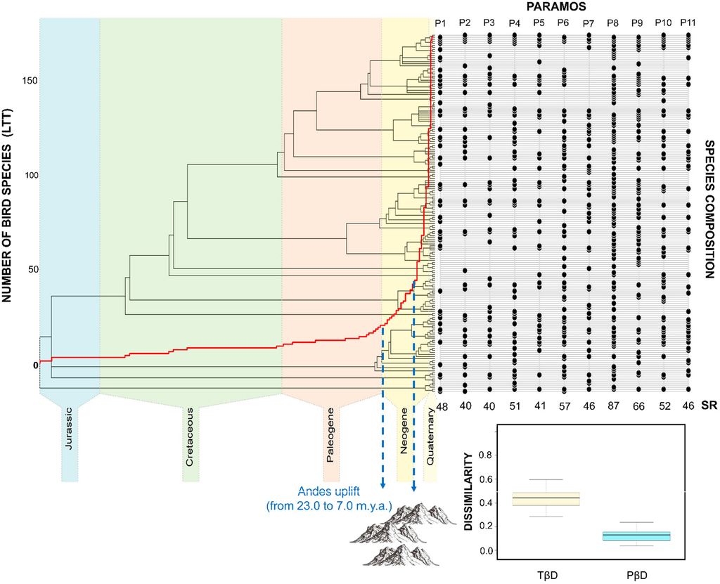

**FIGURE 2**

Time-calibrated tree (Jetz et al., 2012) of the 175 bird species that occurred in the 11 paramos (P1 to P11) distributed in the departments of Nariño and Cauca, Colombia. Red line in the tree represents the lineage through time (LTT). Dashed blue lines represent the estimated period of the most intense peak of Andean mountain building (from 23.0 to 7.0 million years ago). At least, 100 lineages split after this period. Black circles represent the presence of bird species in each Paramo assemblage (P1 to P11, see Tables S1 and S2 for details of Paramos). Species richness are depicted at the bottom of each paramo. Boxplot is showing the total taxonomic (TβD) and phylogenetic (PβD) beta diversity of the 11 assemblages

#### 2.2.6 Phylogenetic beta diversity (PβD)

We pruned the time-calibrated tree proposed by Jetz et al. (2012, https://birdtree.org/) to include the 175 bird species recorded in the 11 paramos. Only three (*Arremon assimilis*, *Arremon atricapillus* and *Scytalopus opacus*) of the 175 species were not present in this tree so we inserted these species as polytomies at the genus level (Figure 2). We calculated phylogenetic turnover using PhyloSor<sub>Turn</sub>, which measures the diversity generated by the replacement of lineages between communities (Leprieur et al., 2012). PhyloSor<sub>Turn</sub> = 1 indicates that two communities do not share any branch in the phylogenetic tree, and PhyloSor<sub>Turn</sub> = 0 indicates that two communities share all branches of the phylogenetic tree.

#### 2.2.7 Standardized effect size (SES)

We calculated SES for TβD and PβD by randomizing species co-occurrences 999 times while maintaining both sample richness and occurrence frequency using the independent swap algorithm (Kembel, 2009) in ‘picante’ R package (Kembel et al., 2010). SES values greater than 1.96 indicate a higher β-diversity than expected by chance, whereas SES values below −1.96 indicate a lower β-diversity than expected by chance.

#### 2.2.8 Lineage through time (LTT)

We computed a LTT plot using the function *mltt.plot* in the ‘ape’ R package (Paradis & Schliep, 2018) to visualize patterns of lineage diversification through time. Our goal was to explore whether signals of temporal increase in the number of species (e.g. change in the slope of the line) corresponded to estimated periods of Andean uplift and/or climatic oscillations in the Pleistocene. We are aware that including only lineages from sampled paramos (i.e. incomplete taxon sampling) might bias the estimation of lineage accumulation. However, we emphasize that are not trying to provide a complete understating of bird diversification in the Andes but trying to associate the pattern of lineage accumulation over time with estimated periods of historic events. Thus, LTT remains a good approach for inferring the relationship between periods of increased species diversification and geologic events hypothesized to influence speciation in the Andean region (e.g. Benício et al., 2021; Skeels & Cardillo, 2019).

## 3 RESULTS

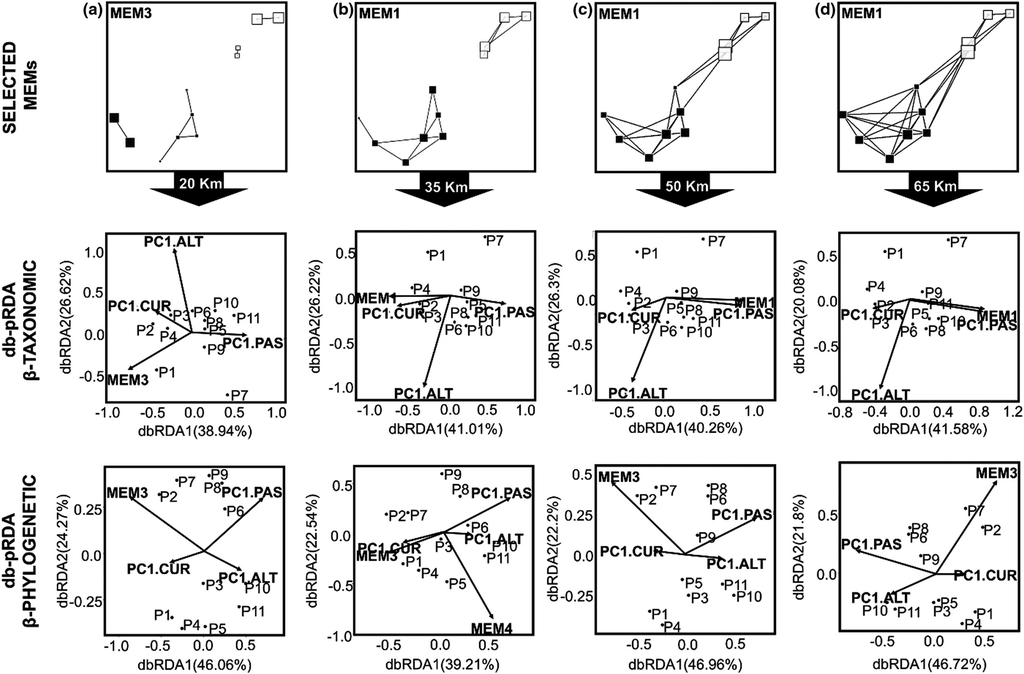

**FIGURE 3**

At top, graphic representation of selected Moran's eigenvector map (MEM) with positive autocorrelation explaining the variation of taxonomic (TβD) and phylogenetic beta diversity (PβD) of bird assemblages in Colombia. MEMs were calculated separately for four classes of spatial neighbourhood by distance – (a) 20 km, (b) 35 km, (c) 50 km, and (d) 65 km – delimiting which paramos are connected (black line). At the centre and bottom, biplot of distance-based partial redundancy analysis (db-pRDA) for TβD and PβD for each class of spatial neighbourhood. We used the first axis of principal components as surrogates for altitude (PC1.ALT), current climate (PC1.CUR) and past climate oscillation (PC1.PAS) gradients

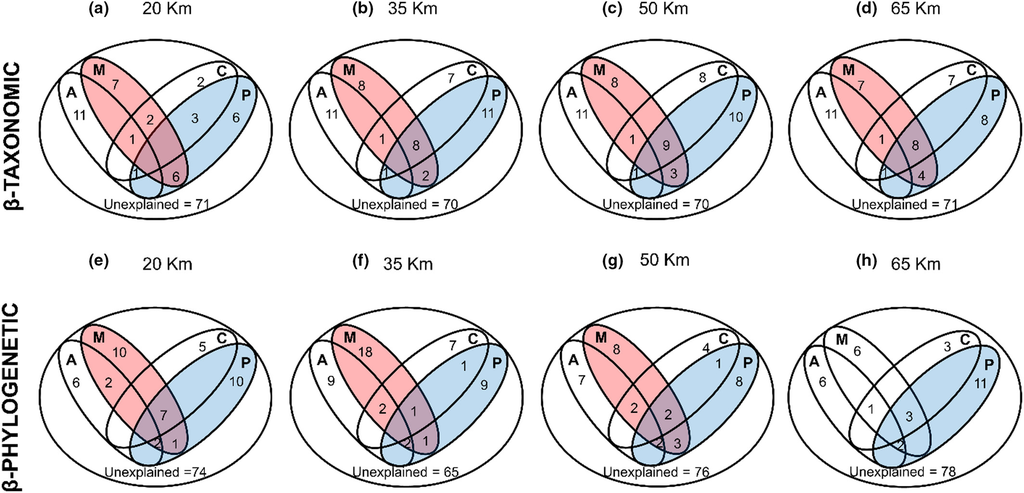

**FIGURE 4**

Variance partition performed separately for each class of spatial neighbourhood – 20 km (a–e), 35 km (b–f), 50 km (c–g), and 65 km (d–h) – for taxonomic (TβD) and phylogenetic beta diversity (PβD) of bird assemblages in Colombia. We used the first axis of principal components as surrogates for altitude (PC1.ALT – A), current climate (PC1.CUR – C), and past climate oscillation (PC1.PAS – P) gradients, and Moran's eigenvector map (MEM – M) as surrogates for connectivity explaining the variation of TβD (a–d) and PβD (e–h) of bird assemblages. Background colors in VP indicate significant at level of 0.05

## 4 DISCUSSION

High taxonomic β-diversity, in conjunction with relatively low phylogenetic β-diversity, across bird assemblages indicates that both speciation and dispersal influence diversity patterns in paramo ecosystems. The LTT indicates that the splitting age of two-thirds of the bird species overlap the late Miocene/early Pliocene, suggesting that the final phase of the Andean uplift had an important role in bird diversification in this ecosystem (Fjeldså, 1994; Fjeldså et al., 2012; Fjeldså & Rahbek, 1997; Hazzi et al., 2018; Ribas et al., 2007). Several studies have shown that young bird radiations are common in mountainous regions, which are centres of endemism and speciation resulting from geological and orogenetic dynamics that created dispersal barriers and opportunities for reduced gene flow (Antonelli et al., 2018; Fjeldså et al., 2012; Graham et al., 2014; Hoorn et al., 2010; Ricklefs, 2003; Weir, 2006). In terms of dispersal, the spatial structure of paramos, with a northern and southern group, indicates that dispersal limitation likely explains patterns of β-diversity. β-diversity seems to be associated with range expansion and contraction of paramos during cyclic climatic changes, such that taxonomic and phylogenetic β-diversity are more distinct as distance between paramos increases from a north-south direction. Taken together, our results reinforce the idea that integrating historical signals into community ecology can provide insight into the relative importance of evolutionary and ecological factors associated with patterns of present-day species distribution (da Silva et al., 2014; Graham & Fine, 2008; Penone et al., 2016; Weinstein et al., 2014).

Lower phylogenetic β-diversity relative to taxonomic β-diversity is consistent with species being replaced (turnover) by closely related ones. Graham et al. (2009), evaluating hummingbird communities in the Andes, and Qian et al. (2013), evaluating regional floras in North America, also found that despite the large differences in species composition, isolated assemblages are largely composed of the same phylogenetic components (i.e. the same genera and families). This pattern is similar for paramo flora of recent origin, from 3 to 5 Ma, where isolation has been suggested as a main factor explaining the low number of endemic genera, but high species turnover and endemism (Londoño et al., 2014; Morales et al., 2007; Van der Hammen, 1997). This scenario is often explained by vicariance events resulting in isolation between mountains or on opposite sides of the same mountain (i.e. allopatric speciation) and divergence from differential selection along elevational gradient within the same mountain (i.e. parapatric speciation; Fjeldså & Rahbek, 2006; Garciá-Moreno & Fjeldså, 2000; Hazzi et al., 2018; Kattan & Franco, 2004; Moritz et al., 2000; Rahbek, 1995; Terborgh, 1977). Although the LTT indicates that the uplift history of the Andes had an important role in speciation burst since Miocene, our data do not allow us to differentiate between allopatric and parapatric speciation. However, both models of speciation are considered plausible in the diversification of the Andean avifauna (Dehling et al., 2014; Fjeldså et al., 2012; Garciá-Moreno & Fjeldså, 2000; Hazzi et al., 2018; Ribas et al., 2007). In allopatric speciation, considered the dominant mode of speciation in birds, the range of a widespread ancestor is fragmented as result of mountain uplift resulting in the origination of new species (see García-Moreno & Fjeldså, 2000; Hazzi et al., 2018; Ribas et al., 2007; Winger et al., 2015). In this scenario, speciation would increase the taxonomic β-diversity, but not the phylogenetic β-diversity between paramos. For parapatric speciation, elevational gradients promote a diversity of ecosystems and each ecosystem has its unique specialized bird composition (Dehling et al., 2014; Fjeldså et al., 2012; Herzog et al., 2005; McCain, 2009; Terborgh, 1977). In this scenario, if speciation occurs along elevational bands within the same mountain, then it would increase the taxonomic β-diversity between isolated paramos. The origin of a new species would not affect phylogenetic β-diversity because the new species would belong to the same genus already present in other paramos. Thus, current patterns of β-diversity cannot be understood based only on a particular event or mechanism. In fact, several studies emphasized that Andean avifauna has been shaped by complex orographic and climate dynamics (Antonelli et al., 2009; Chesser, 2000; Hazzi et al., 2018; Hoorn et al., 2010; Ribas et al., 2007).

## 5 CONCLUSION

Overall, patterns of β-diversity distribution reflect the complex history of Andean region including mountain uplift and climatic oscillations in the Pleistocene that have influenced diversification rates and dispersal among paramos (Antonelli et al., 2009; Hazzi et al., 2018; Hoorn et al., 2010; Ribas et al., 2007). Over the past decades, the development and advances of molecular methods and tools delimiting phylogenetic relationships has provided new insights on the origins and geographic history of bird speciation and dispersal in the Andes (Garcıá-Moreno & Fjeldså, 2000; Pérez-Emán, 2005; Ribas et al., 2007; Winger et al., 2015). However, there are still few studies evaluating how these historical processes have influenced the current spatial distribution of taxonomic and phylogenetic assemblages in this region (e.g. Kattan et al., 2004 at broad spatial extent). Here, we show that integrating historical and ecological biogeography with different facets of β-diversity can provide some insight into the importance of evolutionary and contemporary factors shaping paramo assemblages. β-diversity is being increasingly used as an alternative biodiversity metric, as opposed to species richness, to guide spatial conservation planning (Kattan et al., 2004; Socolar et al., 2016). Our results on the spatial distribution of different components of the β-diversity emphasize the importance of considering β-diversity in conservation planning to preserve the species or evolutionary diversity of paramos biota.

## ACKNOWLEDGEMENTS

We thank Diogo B. Provete for reviewing the first version of the manuscript. E.V.C.-A. thanks Conselho Nacional de Desenvolvimento Científico e Tecnológico (CNPq; Grant/Award Number: 144555/4) for her master scholarship. F.R.dS. thanks Fundação de Amparo à Pesquisa do Estado de São Paulo (FAPESP, Proc. 2013/50714-0 within the BIOTA/FAPESP Program) for financial support during the writing of the paper. C.G. acknowledges the funding support from the European Research Council (ERC) under the European Union’s Horizon 2020 program (grant No 787638). No permits were required for the study.

## CONFLICTS OF INTEREST

The authors declare that they have no conflict of interest regarding this publication.

## BIOSKETCH

**Edna V. Calpa-Anaguano** is a biologist graduated at University of Nariño, Colombia. This work represents a component of her master’s degree in Ecology and Natural Resources (PPGERN) at Universidade Federal de São Carlos- UFSCar, Brazil. She is interested in conservation and sustainable use of biodiversity.

**Catherine Graham** is a senior scientist and group leader of Spatial Evolutionary Ecology at Swiss Federal Research Institute (WSL) with interests in macroecology, tropical ecology, avian biology, and conservation.

**Fernando R. da Silva** is the leader of the Laboratório de Ecologia Teórica: Integrando Tempo, Biologia e Espaço (LET.IT.BE - https://fernandoecologia.wixsite.com/fernandorodrigues) with interests in ecological, evolutionary, and biogeographical processes shaping community assemblages.

*Author contributions*: E.V.C-A. downloaded and analysed the data and wrote the first draft of the manuscript. F.R.S. conceived the original idea for the study, assisted with analyses and led the final writing. C.G. made theoretical contributions. All authors read and approved the final manuscript.

[figure not shown]